# PD5

Wojciech Bogucki

29 kwietnia 2019

# Wstęp

Do pracy domowej użyłem zbioru `titanic` z pakietu DALEX oraz informacji z artykułu [Tunability: Importance of Hyperparameters of Machine Learning Algorithms](https://arxiv.org/pdf/1802.09596.pdf).

Zbiór `titanic` podzieliłem na zbiory treningowy(60%), walidacyjny(20%) i testowy(20%).

# Porównanie modeli

W podanym artykule jako najważniejsze hiperparametry modelu drzew decyzyjnych z pakietu `rpart` wskazane są:

- cp - jeżeli dopasowanie modelu nie poprawi się po wykonaniu podziału o tę wartość, podział nie jest wykonywany
- maxdepth - maksymalna głębokość drzewa decyzyjnego
- minbucket - minimalna liczba obserwacji w liściu
- minsplit - minimalna liczba obesrwacji, przy której może jeszcze nastąpić podział

## Hiperparametry z artykułu

Jako pierwsze testowałem hiperparametry zaproponowane w artykule podanym we wstępie.

```r
model_opt <- rpart(survived~., data=data_train, control = rpart.control(cp=0, maxdepth = 21, minbucket = 12, minsplit = 24))

pred_opt <- predict(model_opt, newdata = data_test)

auc_opt <- measureAUC(pred_opt[,2],truth = data_test$survived, positive = "yes", negative = "no")
```

## Domyślne hiperparametry

Następnie stworzyłem model z domyślnymi parametrami zapropowanymi przez twórców pakietu.

```r
model_def <- rpart(survived~., data=data_train)

pred_def <- predict(model_def, newdata = data_test)
auc_def <- measureAUC(pred_def[,2],truth = data_test$survived, positive = "yes", negative = "no")
```

## Hiperparametry otrzymane metodą random search

Na koniec wybrałem hiperparametry zwrócone przez funkcję `tuneParams` z pakietu `mlr`, które zostały znalezione metodą random search.

```r
train_task_data <- rbind(data_train, data_valid)
size <- nrow(train_task_data)
train_ind <- seq_len(nrow(data_train))
validation_ind <- seq.int(max(train_ind) + 1, size)

rpart_pars <- tuneParams(learner = makeLearner("classif.rpart", predict.type = "prob"),
           task = makeClassifTask(id="rpart_task", data = train_task_data, target = "survived"),
           resampling = makeFixedHoldoutInstance(train_ind, validation_ind, size),
           measures = auc,
           par.set = makeParamSet(makeNumericParam("cp",0,1),
                                  makeIntegerParam("maxdepth",1,30),
                                  makeIntegerParam("minsplit",1,60),
                                  makeIntegerParam("minbucket",1,60)),
           control = makeTuneControlRandom(maxit = 500),
           show.info = FALSE)

model_rand <- rpart(survived~., data=data_train, control = rpart.control(cp=rpart_pars$x$cp,
                                                                         maxdepth = rpart_pars$x$maxdepth,
                                                                         minbucket = rpart_pars$x$minbucket,
                                                                         minsplit = rpart_pars$x$minsplit))

pred_rand <- predict(model_rand, newdata = data_test)
auc_rand <- measureAUC(pred_rand[,2],truth = data_test$survived, positive = "yes", negative = "no")
```

## Porównanie

Jakość modeli mierzona za pomocą AUC oraz użyte hiperparametry znajdują się w poniższej tabeli:

[output not shown]

Najlepsze AUC uzyskał model mający hiperparametry podane w artykule, gorszy wynik miał model z hiperparametrami znalezionymi metodą random search, a najgorszy wynik miał model z domyślnymi hiperparametrami.

# Drzewo decyzyjne

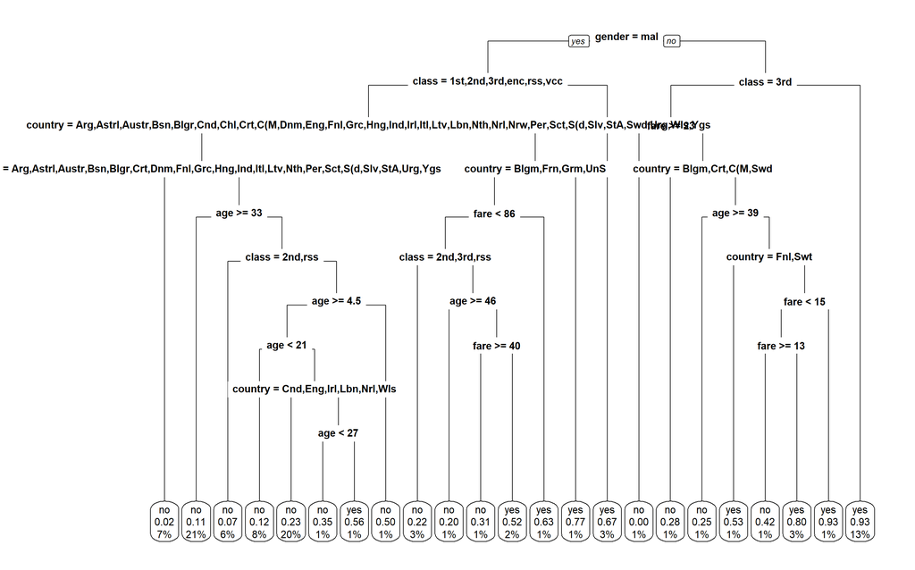

Drzewo decyzyjne dla najlepszego modelu

A tak prezentują się reguły decyzyjne tego drzewa zapisane w tabeli:

Reguły decyzyjne najlepszego modelu

[output not shown]

# Wpływ kryterium podziału na wyniki

Domyślnym kryterium podziału jest indeks Giniego. Tworzę teraz model z kryterium podziału Information Gain, które wybiera podział najbardziej zmniejszający entropię targetu(oraz z hiperparametrami poleconymi w artykule).

```r
model_opt2 <- rpart(survived~., data=data_train, control = rpart.control(cp=0, maxdepth = 21, minbucket = 12, minsplit = 24), parms = list(split = 'information'))

pred_opt2 <- predict(model_opt2, newdata = data_test)

auc_opt2 <- measureAUC(pred_opt2[,2],truth = data_test$survived, positive = "yes", negative = "no")
```

W tym przypadku Zmiana kryterium podziału pogorszyła AUC, co widać w poniższej tabeli

| Podzial | AUC |
| --- | --- |
| Gini | 0.7922851 |
| Information Gain | 0.7783668 |